# Bayesian GLMM Part1

  If the ratios are low, tightening the priors may help.

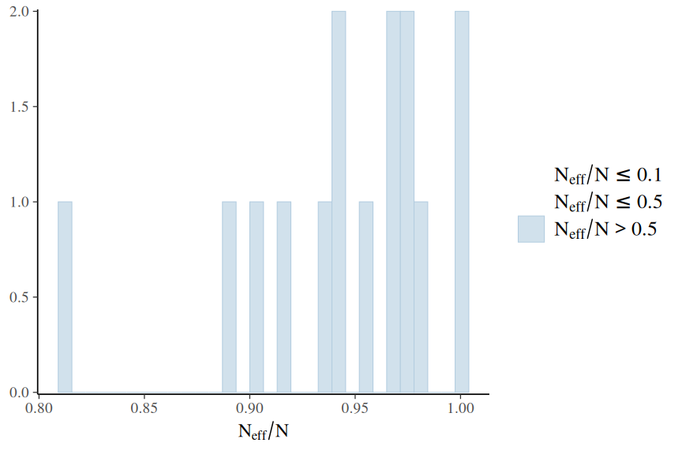

```r
tobacco_brm2 |> mcmc_plot(type='neff_hist')
```

Ratios all very high.

**More diagnostics**

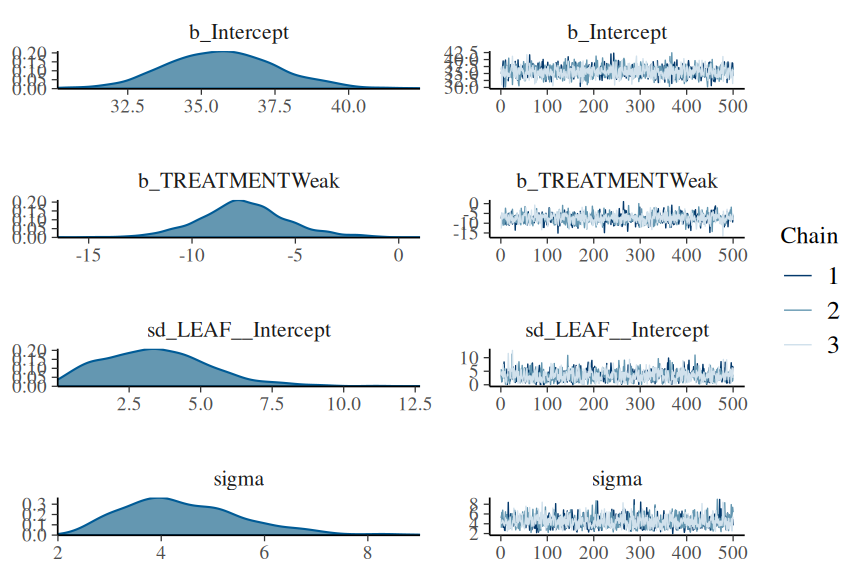

```r
tobacco_brm3 |> mcmc_plot(type='combo')
```

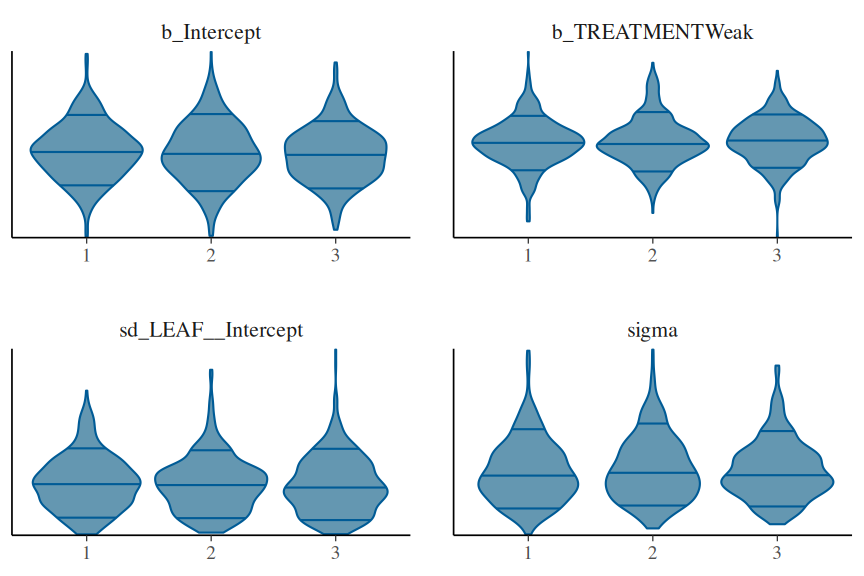

```r
tobacco_brm3 |> mcmc_plot(type='violin')
```

**stan plots**

The `rstan` package offers a range of MCMC diagnostics. Lets start with the MCMC diagnostics.

Of these, we will focus on:

- stan_trace: this plots the estimates of each parameter over the post-warmup length of each MCMC chain. Each chain is plotted in a different colour, with each parameter in its own facet. Ideally, each **trace** should just look like noise without any discernible drift and each of the traces for a specific parameter should look the same (i.e, should not be displaced above or below any other trace for that parameter).

```r
tobacco_brm3 |> get_variables()
```

```
 [1] "b_Intercept"          "b_TREATMENTWeak"      "sd_LEAF__Intercept"
 [4] "sigma"                "Intercept"            "r_LEAF[L1,Intercept]"
 [7] "r_LEAF[L2,Intercept]" "r_LEAF[L3,Intercept]" "r_LEAF[L4,Intercept]"
[10] "r_LEAF[L5,Intercept]" "r_LEAF[L6,Intercept]" "r_LEAF[L7,Intercept]"
[13] "r_LEAF[L8,Intercept]" "prior_Intercept"      "prior_b"
[16] "prior_sigma"          "prior_sd_LEAF"        "lprior"
[19] "lp__"                 "accept_stat__"        "stepsize__"
[22] "treedepth__"          "n_leapfrog__"         "divergent__"
[25] "energy__"
```

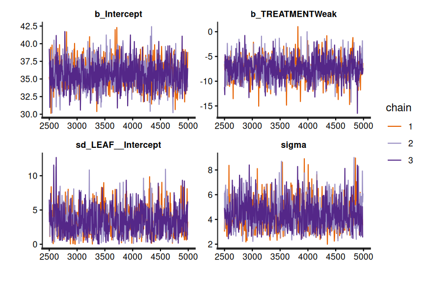

```r
pars <- tobacco_brm3 |> get_variables()
pars <- str_extract(pars, '^b_.*|^sigma$|^sd.*') |> na.omit()

tobacco_brm3$fit |> stan_trace(pars = pars)
```

The chains appear well mixed and very similar

- stan_acf (autocorrelation function): plots the autocorrelation between successive MCMC sample lags for each parameter and each chain

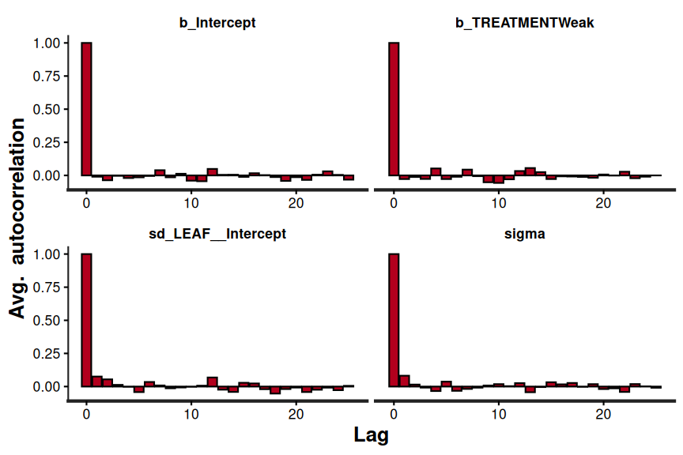

```r
tobacco_brm3$fit |>
    stan_ac(pars = pars)
```

There is no evidence of autocorrelation in the MCMC samples

- stan_rhat: Rhat is a **scale reduction factor** measure of convergence between the chains. The closer the values are to 1, the more the chains have converged. Values greater than 1.05 indicate a lack of convergence. There will be an Rhat value for each parameter estimated.

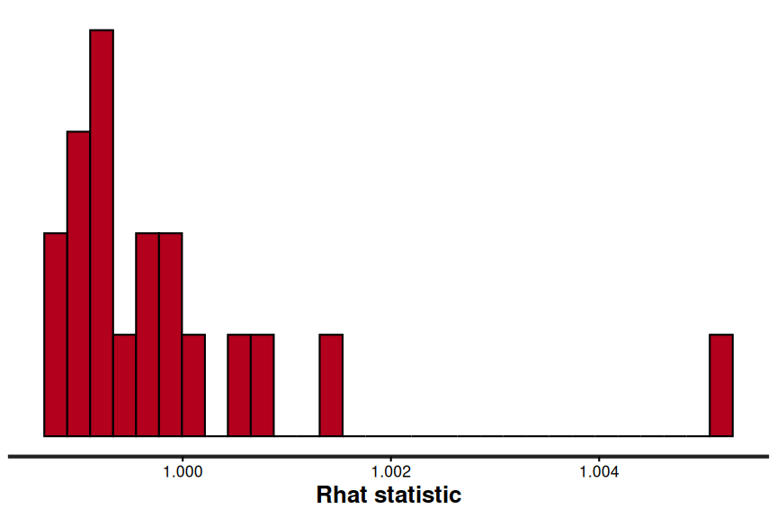

```r
tobacco_brm3$fit |> stan_rhat()
```

All Rhat values are below 1.05, suggesting the chains have converged.

- stan_ess (number of effective samples): the ratio of the number of effective samples (those not rejected by the sampler) to the number of samples provides an indication of the effectiveness (and efficiency) of the MCMC sampler. Ratios that are less than 0.5 for a parameter suggest that the sampler spent considerable time in difficult areas of the sampling domain and rejected more than half of the samples (replacing them with the previous effective sample).

  If the ratios are low, tightening the priors may help.

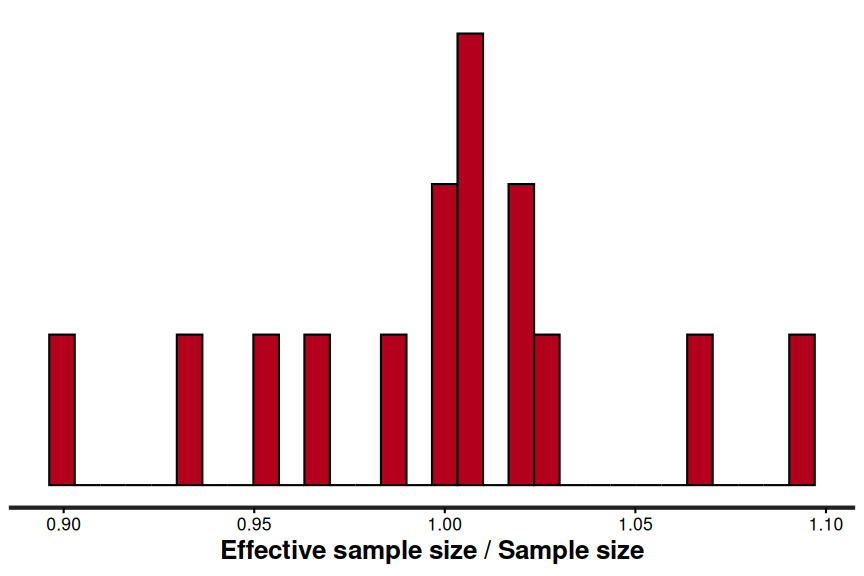

```r
tobacco_brm2$fit |> stan_ess()
```

Ratios all very high.

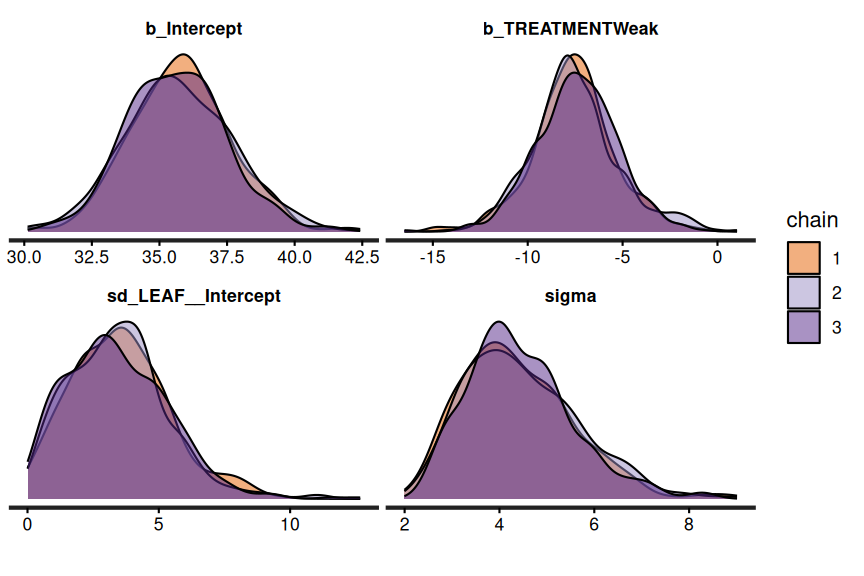

```r
tobacco_brm3$fit |>
    stan_dens(separate_chains = TRUE, pars = pars)
```

**ggmcmc**

The `ggmean` package also as a set of MCMC diagnostic functions. Lets start with the MCMC diagnostics.

Of these, we will focus on:

- ggs_traceplot: this plots the estimates of each parameter over the post-warmup length of each MCMC chain. Each chain is plotted in a different colour, with each parameter in its own facet. Ideally, each **trace** should just look like noise without any discernible drift and each of the traces for a specific parameter should look the same (i.e, should not be displaced above or below any other trace for that parameter).

[figure not shown]

```r
tobacco_ggs <- tobacco_brm3 |> ggs(burnin = FALSE, inc_warmup = FALSE)
tobacco_ggs |> ggs_traceplot()
```

The chains appear well mixed and very similar

- gss_autocorrelation (autocorrelation function): plots the autocorrelation between successive MCMC sample lags for each parameter and each chain

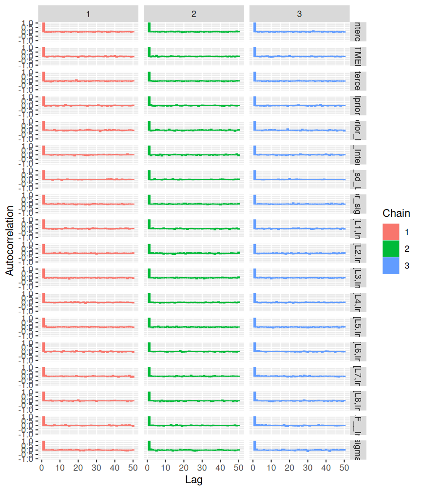

```r
ggs_autocorrelation(tobacco_ggs)
```

There is no evidence of autocorrelation in the MCMC samples

- stan_rhat: Rhat is a **scale reduction factor** measure of convergence between the chains. The closer the values are to 1, the more the chains have converged. Values greater than 1.05 indicate a lack of convergence. There will be an Rhat value for each parameter estimated.

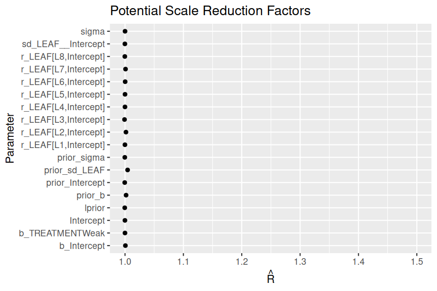

```r
ggs_Rhat(tobacco_ggs)
```

All Rhat values are below 1.05, suggesting the chains have converged.

- stan_ess (number of effective samples): the ratio of the number of effective samples (those not rejected by the sampler) to the number of samples provides an indication of the effectiveness (and efficiency) of the MCMC sampler. Ratios that are less than 0.5 for a parameter suggest that the sampler spent considerable time in difficult areas of the sampling domain and rejected more than half of the samples (replacing them with the previous effective sample).

  If the ratios are low, tightening the priors may help.

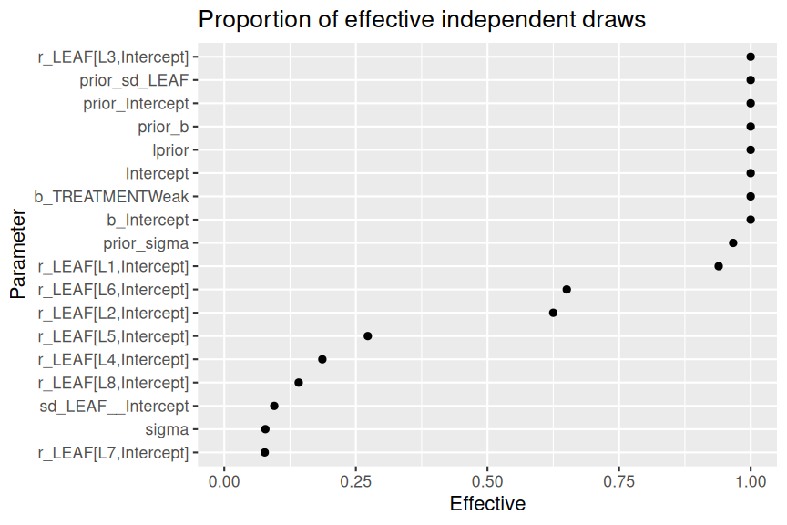

```r
ggs_effective(tobacco_ggs, version_effective = "BDA3")
```

**More diagnostics**

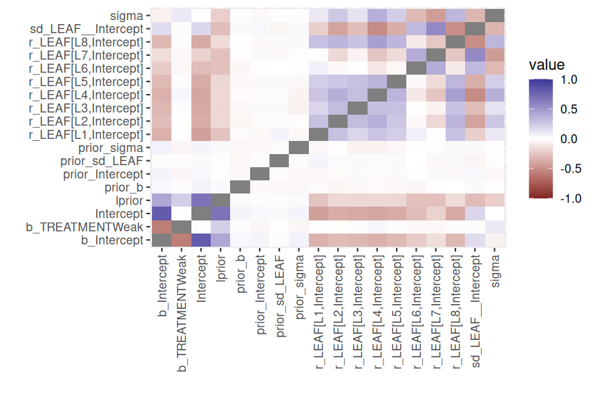

```r
ggs_crosscorrelation(tobacco_ggs)
```

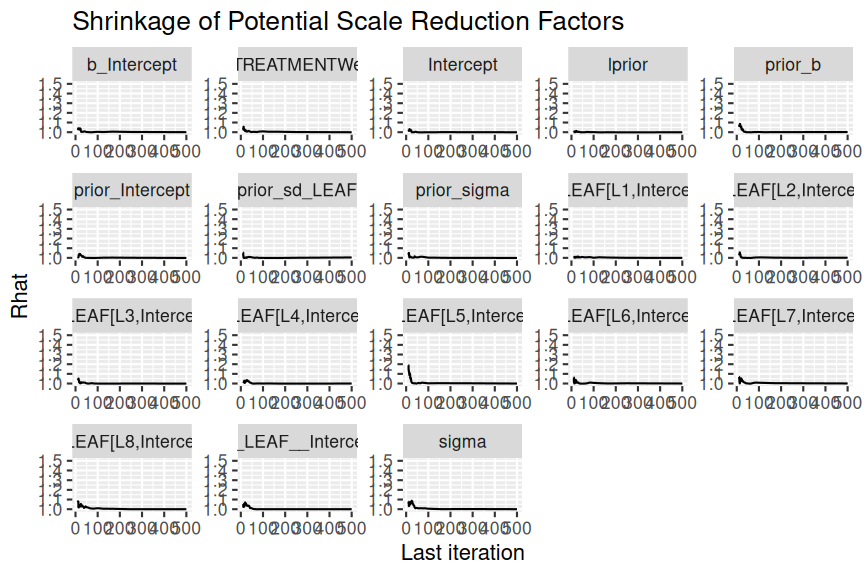

```r
ggs_grb(tobacco_ggs)
```

**pp check**

Post predictive checks provide additional diagnostics about the fit of the model. Specifically, they provide a comparison between predictions drawn from the model and the observed data used to train the model.

**See list of available diagnostics by name**

```r
available_ppc()
```

```
bayesplot PPC module:
  ppc_bars
  ppc_bars_grouped
  ppc_boxplot
  ppc_calibration
  ppc_calibration_grouped
  ppc_calibration_overlay
  ppc_calibration_overlay_grouped
  ppc_dens
  ppc_dens_overlay
  ppc_dens_overlay_grouped
  ppc_dots
  ppc_ecdf_overlay
  ppc_ecdf_overlay_grouped
  ppc_error_binned
  ppc_error_hist
  ppc_error_hist_grouped
  ppc_error_scatter
  ppc_error_scatter_avg
  ppc_error_scatter_avg_grouped
  ppc_error_scatter_avg_vs_x
  ppc_freqpoly
  ppc_freqpoly_grouped
  ppc_hist
  ppc_intervals
  ppc_intervals_grouped
  ppc_km_overlay
  ppc_km_overlay_grouped
  ppc_loo_calibration
  ppc_loo_calibration_grouped
  ppc_loo_intervals
  ppc_loo_pit_ecdf
  ppc_loo_pit_overlay
  ppc_loo_pit_qq
  ppc_loo_ribbon
  ppc_pit_ecdf
  ppc_pit_ecdf_grouped
  ppc_ribbon
  ppc_ribbon_grouped
  ppc_rootogram
  ppc_rootogram_grouped
  ppc_scatter
  ppc_scatter_avg
  ppc_scatter_avg_grouped
  ppc_stat
  ppc_stat_2d
  ppc_stat_freqpoly
  ppc_stat_freqpoly_grouped
  ppc_stat_grouped
  ppc_violin_grouped
```

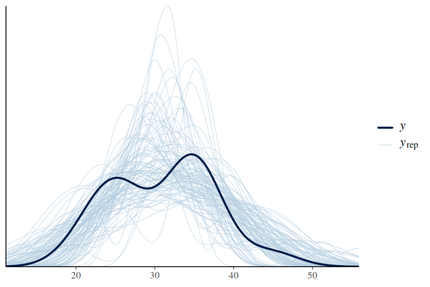

```r
tobacco_brm3 |> pp_check(type = 'dens_overlay', ndraws = 100)
```

The model draws appear to be consistent with the observed data.

- error_scatter_avg: this plots the observed values against the average residuals. Similar to a residual plot, we do not want to see any patterns in this plot. Note, this is not really that useful for models that involve a binomial response

```r
#tobacco_brm3 |> pp_check(type = 'error_scatter_avg')
```

This is not really interpretable

- intervals: plots the observed data overlayed ontop of posterior predictions associated with each level of the predictor. Ideally, the observed data should all fall within the predictive intervals.

```
Using all posterior draws for ppc type 'intervals' by default.
```

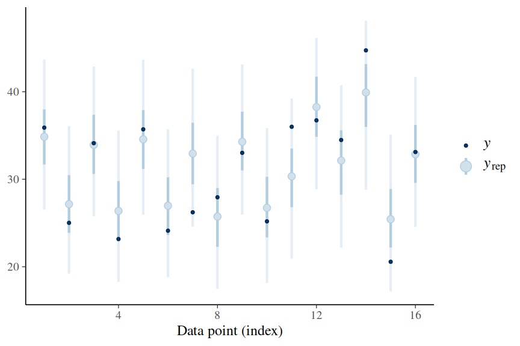

```r
tobacco_brm3 |> pp_check(group = 'TREATMENT', type = 'intervals')
```

```
Using all posterior draws for ppc type 'intervals_grouped' by default.
```

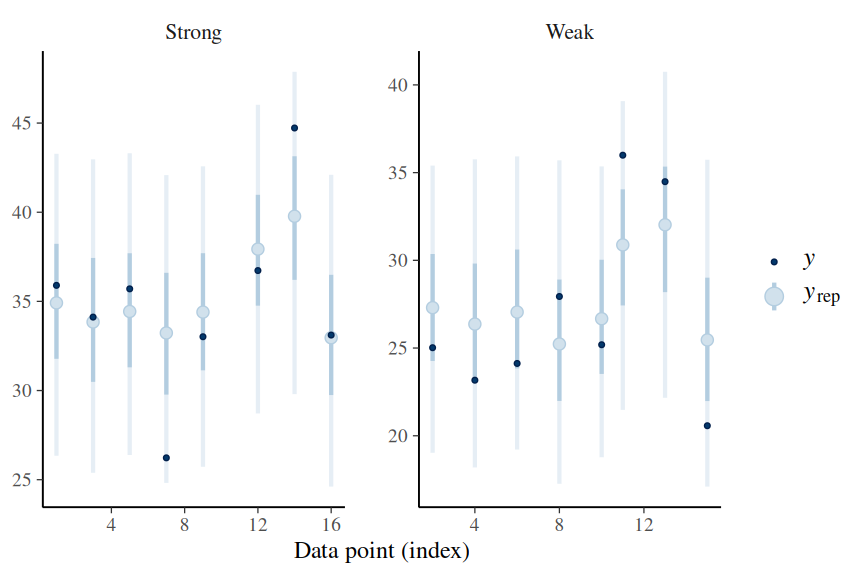

```r
tobacco_brm3 |> pp_check(group = 'TREATMENT', type = 'intervals_grouped')
```

```
Using all posterior draws for ppc type 'violin_grouped' by default.
```

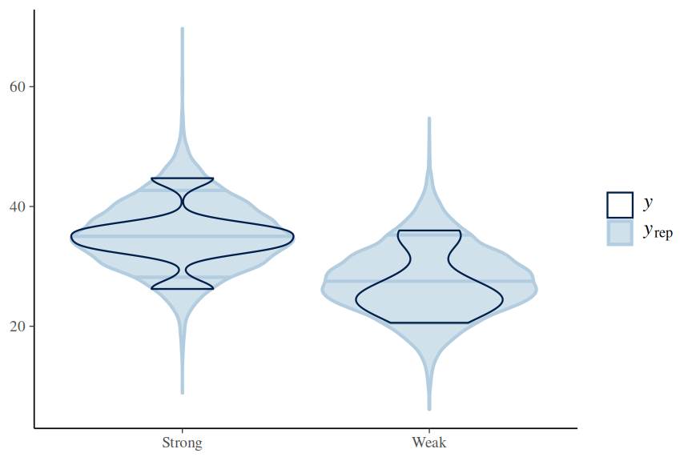

```r
tobacco_brm3 |> pp_check(group = 'TREATMENT', type = 'violin_grouped')
```

The `shinystan` package allows the full suite of MCMC diagnostics and posterior predictive checks to be accessed via a web interface.

```r
#library(shinystan)
#launch_shinystan(tobacco_brm2)
```

**DHARMa residuals**

DHARMa residuals provide very useful diagnostics. Unfortunately, we cannot directly use the `simulateResiduals()` function to generate the simulated residuals. However, if we are willing to calculate some of the components ourself, we can still obtain the simulated residuals from the fitted stan model.

We need to supply:

- simulated (predicted) responses associated with each observation.
- observed values
- fitted (predicted) responses (averaged) associated with each observation

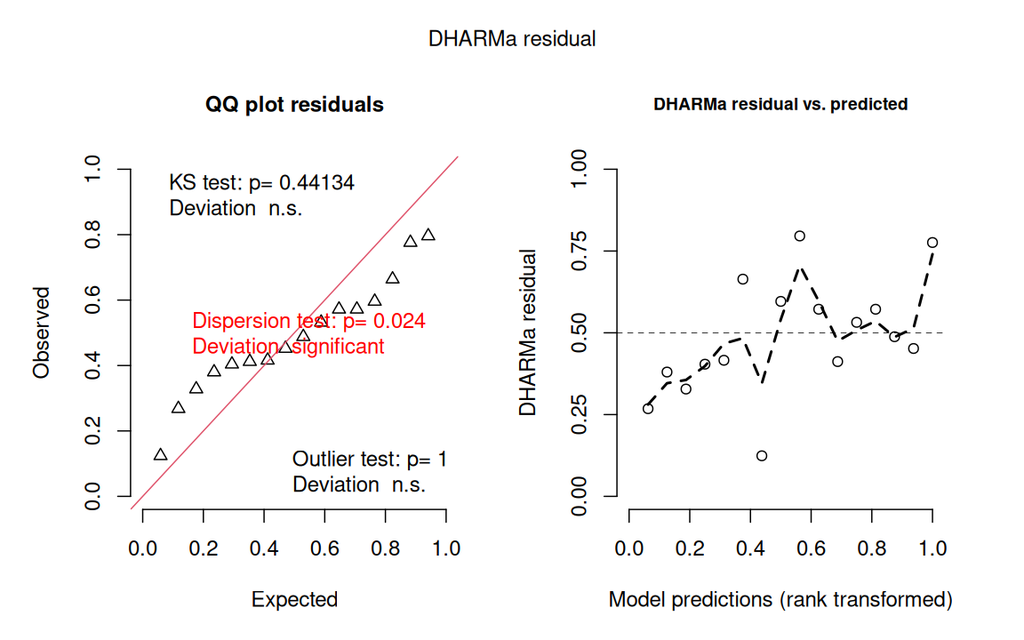

```r
preds <- tobacco_brm4 |> posterior_predict(ndraws = 250,  summary = FALSE)
tobacco_resids <- createDHARMa(simulatedResponse = t(preds),
                            observedResponse = tobacco$NUMBER,
                            fittedPredictedResponse = apply(preds, 2, median),
                            integerResponse = FALSE)
plot(tobacco_resids, quantreg = FALSE)
```

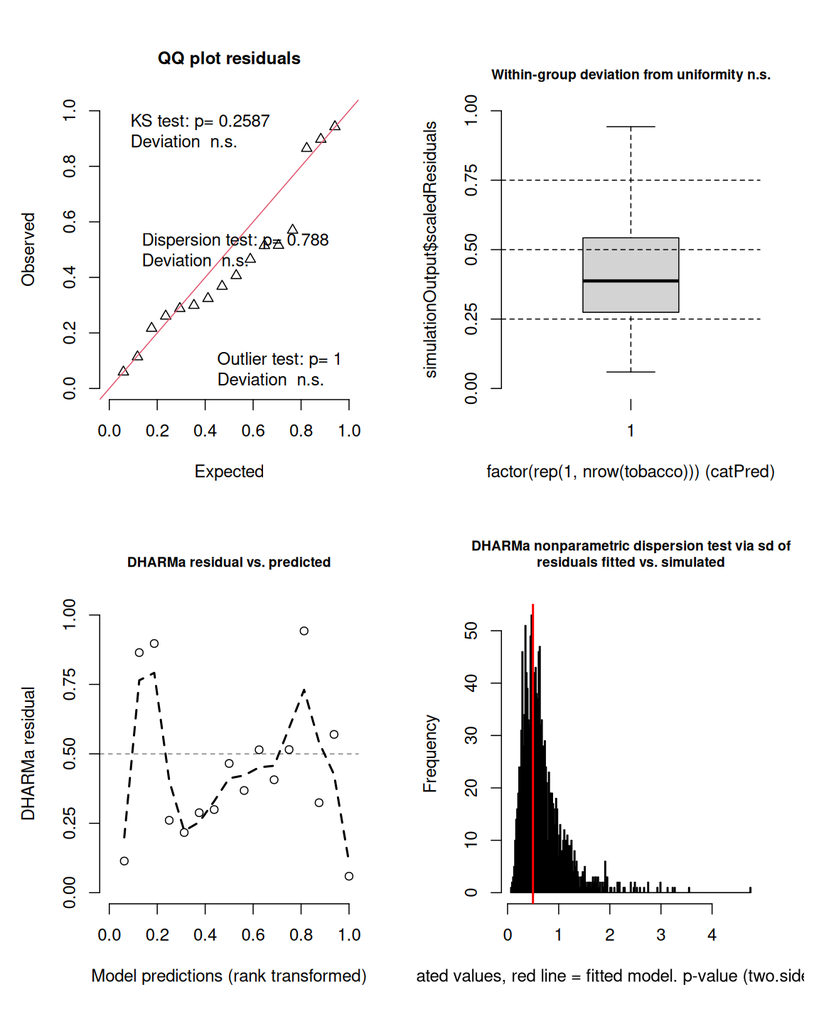

```r
tobacco_resids <- make_brms_dharma_res(tobacco_brm3, integerResponse = FALSE)
wrap_elements(~testUniformity(tobacco_resids)) +
               wrap_elements(~plotResiduals(tobacco_resids, form = factor(rep(1, nrow(tobacco))))) +
               wrap_elements(~plotResiduals(tobacco_resids, quantreg = FALSE)) +
               wrap_elements(~testDispersion(tobacco_resids))
```

**Conclusions:**

# 7 Partial effects plots

**brms**

**conditional_effects**

```
Ignoring unknown labels:
• fill : "NA"
• colour : "NA"
Ignoring unknown labels:
• fill : "NA"
• colour : "NA"
```

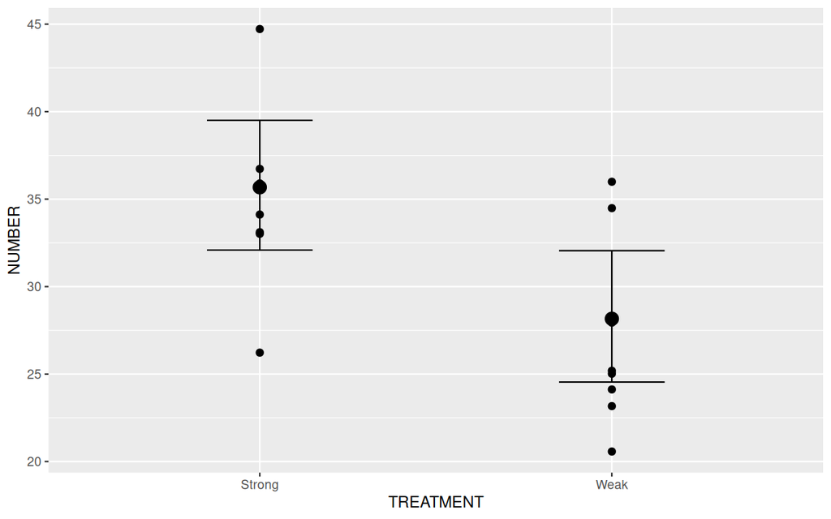

```r
tobacco_brm3 |>
    conditional_effects() |>
    plot(points = TRUE)
```

**ggpredict**

```
Note: uncertainty of error terms are not taken into account. Consider
  setting `interval` to "prediction". This will call `posterior_predict()`
  instead of `posterior_epred()`.
```

```
Data points may overlap. Use the `jitter` argument to add some amount of
  random variation to the location of data points and avoid overplotting.
```

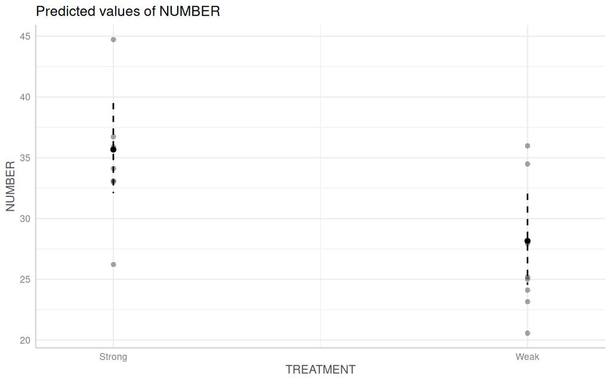

```r
tobacco_brm3 |>
    ggpredict() |>
    plot(show_data = TRUE)
```

**ggemmeans**

```
Data points may overlap. Use the `jitter` argument to add some amount of
  random variation to the location of data points and avoid overplotting.
```

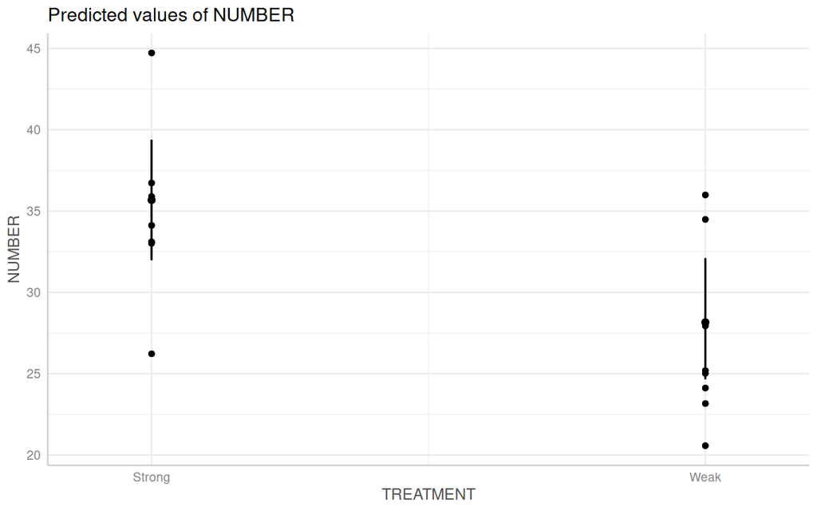

```r
tobacco_brm3 |>
    ggemmeans(~TREATMENT) |>
    plot(show_data = TRUE) +
    geom_point(data = tobacco, aes(y = NUMBER, x = as.numeric(TREATMENT)))
```

**fitted_draws**

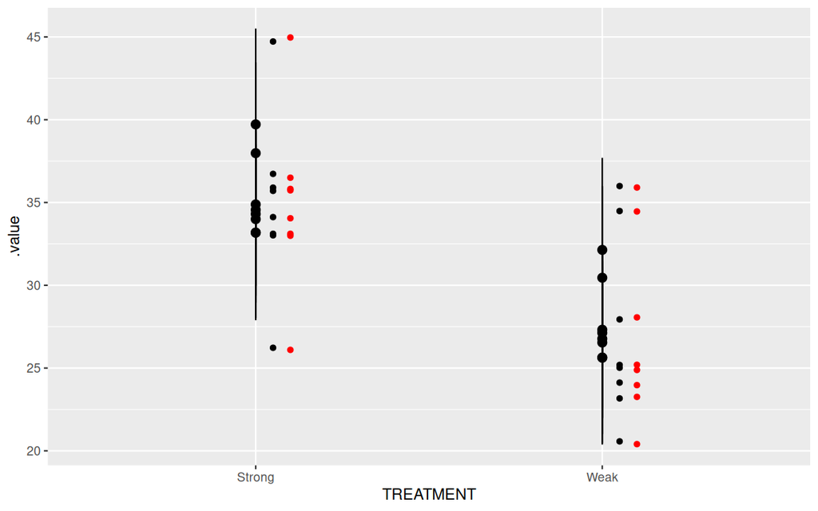

```r
Partial.obs <- tobacco_brm3$data |>
    mutate(Pred = predict(tobacco_brm3)[,'Estimate'],
           Resid = resid(tobacco_brm3)[,'Estimate'],
           Obs = Pred + Resid)

tobacco_brm3 |>
    fitted_draws(newdata = tobacco) |>
    median_hdci() |>
    ggplot(aes(x = TREATMENT, y = .value)) +
    geom_pointrange(aes(ymin = .lower, ymax = .upper)) +
    geom_line() +
    geom_point(data = Partial.obs,  aes(y = Obs,  x = TREATMENT), color = 'red',
               position = position_nudge(x = 0.1)) +
    geom_point(data = tobacco,  aes(y = NUMBER,  x = TREATMENT),
               position = position_nudge(x = 0.05))
```

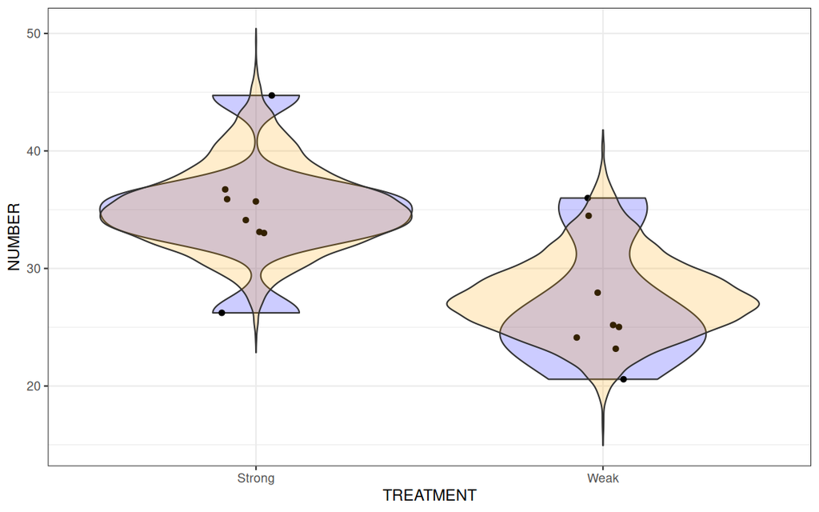

```r
tobacco_brm3 |>
    epred_draws(newdata = tobacco) |>
    ggplot() +
    geom_violin(data = tobacco, aes(y = NUMBER, x = TREATMENT), fill = 'blue', alpha = 0.2) +
    geom_point(data = tobacco, aes(y = NUMBER, x = TREATMENT),
               position = position_jitter(width = 0.1, height = 0)) +
    geom_violin(aes(y = .epred, x = TREATMENT), fill = 'orange', alpha = 0.2) +
    theme_bw()
```

# 8 Model investigation

**brms**

**summary**

```r
tobacco_brm3 |> summary()
```

```
 Family: gaussian
  Links: mu = identity
Formula: NUMBER ~ (1 | LEAF) + TREATMENT
   Data: tobacco (Number of observations: 16)
  Draws: 3 chains, each with iter = 5000; warmup = 2500; thin = 5;
         total post-warmup draws = 1500

Multilevel Hyperparameters:
~LEAF (Number of levels: 8)
              Estimate Est.Error l-95% CI u-95% CI Rhat Bulk_ESS Tail_ESS
sd(Intercept)     3.46      1.89     0.39     7.73 1.00     1138     1382

Regression Coefficients:
              Estimate Est.Error l-95% CI u-95% CI Rhat Bulk_ESS Tail_ESS
Intercept        35.71      1.89    32.09    39.50 1.00     1547     1378
TREATMENTWeak    -7.49      2.19   -11.75    -2.89 1.00     1616     1486

Further Distributional Parameters:
      Estimate Est.Error l-95% CI u-95% CI Rhat Bulk_ESS Tail_ESS
sigma     4.43      1.17     2.63     7.00 1.00     1250     1500

Draws were sampled using sampling(NUTS). For each parameter, Bulk_ESS
and Tail_ESS are effective sample size measures, and Rhat is the potential
scale reduction factor on split chains (at convergence, Rhat = 1).
```

**Conclusions:**

- the intercept indicates that the Strong treatment has an average of 35.71 lesions.
- the Weak treatment has 7.49 fewer lesions.
- the variance in intercepts across all Leaves is 3.46
- the scale of variance between Leaves is very similar to the variance within Leaves (sigma, 4.43).

**summarise_draws**

```r
tobacco_brm3 |>
  summarise_draws(
    median,
    ~ HDInterval::hdi(.x),
    N =  ~ length(.x),
    Pl =  ~mean(.x < 0),
    Pg =  ~mean(.x > 0),
    rhat,
    ess_bulk,
    ess_tail
  )
```

```
# A tibble: 19 × 10
   variable   median    lower  upper     N    Pl      Pg  rhat ess_bulk ess_tail
   <chr>       <dbl>    <dbl>  <dbl> <dbl> <dbl>   <dbl> <dbl>    <dbl>    <dbl>
 1 b_Interc…  35.7    32.0     39.4   1500 0     1       1.00     1547.    1378.
 2 b_TREATM…  -7.57  -11.9     -3.09  1500 0.999 0.00133 1.00     1616.    1486.
 3 sd_LEAF_…   3.35    0.0201   6.73  1500 0     1       1.000    1138.    1382.
 4 sigma       4.26    2.44     6.71  1500 0     1       1.00     1250.    1500.
 5 Intercept  31.9    28.8     34.9   1500 0     1       1.00     1541.    1417.
 6 r_LEAF[L…  -0.575  -5.40     4.38  1500 0.645 0.355   0.999    1499.    1277.
 7 r_LEAF[L…  -1.38   -6.98     2.74  1500 0.747 0.253   1.00     1459.    1352.
 8 r_LEAF[L…  -0.841  -5.98     3.63  1500 0.677 0.323   1.000    1564.    1346.
 9 r_LEAF[L…  -2.16   -8.27     2.46  1500 0.825 0.175   1.00     1339.    1500.
10 r_LEAF[L…  -1.11   -6.13     3.44  1500 0.723 0.277   1.00     1393.    1313.
11 r_LEAF[L…   2.02   -2.16     7.42  1500 0.199 0.801   1.000    1116.    1501.
12 r_LEAF[L…   3.75   -1.19     9.31  1500 0.082 0.918   1.000    1182.    1464.
13 r_LEAF[L…  -2.28   -7.76     2.23  1500 0.837 0.163   0.999    1302.    1381.
14 prior_In…  35.1    28.3     40.5   1500 0     1       1.00     1513.    1500.
15 prior_b    -0.197 -20.8     18.5   1500 0.507 0.493   1.00     1534.    1420.
16 prior_si…   3.71    0.0127  16.2   1500 0     1       1.000    1234.    1408.
17 prior_sd…   3.85    0.0111  16.2   1500 0     1       1.00     1224.    1451.
18 lprior    -10.7   -12.1     -9.90  1500 1     0       0.999    1656.    1421.
19 lp__      -65.2   -72.7    -58.4   1500 1     0       0.999     956.    1313.
```

```r
## or if you want to exclude some parameters
tobacco_brm3 |>
  summarise_draws(
    median,
    ~ HDInterval::hdi(.x),
    rhat,
    ess_bulk,
    ess_tail
  ) |>
  filter(str_detect(variable, 'prior|^r_|^lp__', negate = TRUE))
```

```
# A tibble: 5 × 7
  variable           median    lower upper  rhat ess_bulk ess_tail
  <chr>               <dbl>    <dbl> <dbl> <dbl>    <dbl>    <dbl>
1 b_Intercept         35.7   32.0    39.4  1.00     1547.    1378.
2 b_TREATMENTWeak     -7.57 -11.9    -3.09 1.00     1616.    1486.
3 sd_LEAF__Intercept   3.35   0.0201  6.73 1.000    1138.    1382.
4 sigma                4.26   2.44    6.71 1.00     1250.    1500.
5 Intercept           31.9   28.8    34.9  1.00     1541.    1417.
```

**as_draws_df (posteriors)**

```r
tobacco_brm3 |> as_draws_df()
```

```
# A draws_df: 500 iterations, 3 chains, and 19 variables
   b_Intercept b_TREATMENTWeak sd_LEAF__Intercept sigma Intercept
1           35            -7.7                3.7   5.2        31
2           36            -5.1                1.1   6.0        34
3           36            -7.7                5.1   5.3        32
4           38            -7.9                4.9   5.1        34
5           39           -10.1                4.3   3.3        34
6           30            -6.9                5.1   3.3        27
7           34            -9.2                8.4   4.7        29
8           39            -9.2                4.0   2.7        34
9           36            -8.7                3.9   2.6        32
10          40           -10.4                4.1   5.2        35
   r_LEAF[L1,Intercept] r_LEAF[L2,Intercept] r_LEAF[L3,Intercept]
1                  0.28                -3.50                -0.25
2                 -0.87                -1.71                 0.37
3                 -0.92                -6.51                -2.65
4                 -6.52                -8.89                -4.93
5                 -5.71                -0.45                -1.76
6                  4.11                 4.11                -4.48
7                  9.29                -2.66                 0.44
8                 -1.68                -6.38                -1.98
9                 -3.29                -3.34                -2.25
10                -2.66                -3.27                -1.95
# ... with 1490 more draws, and 11 more variables
# ... hidden reserved variables {'.chain', '.iteration', '.draw'}
```

```r
tobacco_brm3 |>
  as_draws_df() |>
  dplyr::select(matches("^b_.*|^sigma$|^sd_.*")) |>
  summarise_draws(
    median,
    ~ HDInterval::hdi(.x),
    Pg = ~ mean(.x > 0),
    Pl = ~ mean(.x < 0),
    rhat,
    ess_bulk,
    ess_tail
  )
```

```
# A tibble: 4 × 9
  variable           median    lower upper      Pg    Pl  rhat ess_bulk ess_tail
  <chr>               <dbl>    <dbl> <dbl>   <dbl> <dbl> <dbl>    <dbl>    <dbl>
1 b_Intercept         35.7   32.0    39.4  1       0     1.00     1529.    1352.
2 b_TREATMENTWeak     -7.57 -11.9    -3.09 0.00133 0.999 1.00     1606.    1444.
3 sd_LEAF__Intercept   3.35   0.0201  6.73 1       0     1.000    1115.    1348.
4 sigma                4.26   2.44    6.71 1       0     1.000    1229.    1492.
```

```r
## or if you want to exclude some parameters
tobacco_brm3 |>
  as_draws_df() |>
  summarise_draws(
    median,
    ~ HDInterval::hdi(.x),
    rhat,
    ess_bulk,
    ess_tail
  ) |>
  filter(str_detect(variable, 'prior|^r_|^lp__', negate = TRUE))
```

```
# A tibble: 5 × 7
  variable           median    lower upper  rhat ess_bulk ess_tail
  <chr>               <dbl>    <dbl> <dbl> <dbl>    <dbl>    <dbl>
1 b_Intercept         35.7   32.0    39.4  1.00     1547.    1378.
2 b_TREATMENTWeak     -7.57 -11.9    -3.09 1.00     1616.    1486.
3 sd_LEAF__Intercept   3.35   0.0201  6.73 1.000    1138.    1382.
4 sigma                4.26   2.44    6.71 1.00     1250.    1500.
5 Intercept           31.9   28.8    34.9  1.00     1541.    1417.
```

**tidyMCMC**

```r
tobacco_brm3$fit |>
    tidyMCMC(estimate.method = 'median',
             conf.int = TRUE,  conf.method = 'HPDinterval',
             rhat = TRUE, ess = TRUE)
```

```
# A tibble: 18 × 7
   term                 estimate std.error conf.low conf.high  rhat   ess
   <chr>                   <dbl>     <dbl>    <dbl>     <dbl> <dbl> <int>
 1 b_Intercept            35.7       1.89   32.0        39.4  1.000  1531
 2 b_TREATMENTWeak        -7.49      2.19  -11.9        -3.09 1.000  1606
 3 sd_LEAF__Intercept      3.46      1.89    0.0201      6.73 0.999  1161
 4 sigma                   4.43      1.17    2.44        6.71 0.999  1247
 5 Intercept              32.0       1.53   28.8        34.9  0.999  1514
 6 r_LEAF[L1,Intercept]   -0.820     2.38   -5.40        4.38 0.999  1494
 7 r_LEAF[L2,Intercept]   -1.76      2.54   -6.98        2.74 1.00   1447
 8 r_LEAF[L3,Intercept]   -1.09      2.39   -5.98        3.63 0.999  1517
 9 r_LEAF[L4,Intercept]   -2.52      2.76   -8.27        2.46 1.00   1353
10 r_LEAF[L5,Intercept]   -1.42      2.45   -6.13        3.44 1.00   1385
11 r_LEAF[L6,Intercept]    2.25      2.59   -2.16        7.42 1.000  1153
12 r_LEAF[L7,Intercept]    3.82      2.95   -1.19        9.31 1.000  1116
13 r_LEAF[L8,Intercept]   -2.59      2.67   -7.76        2.23 0.999  1319
14 prior_Intercept        35.0       3.09   28.3        40.5  1.000  1501
15 prior_b                -0.178     9.97  -20.8        18.5  1.00   1527
16 prior_sigma             5.39      5.82    0.0127     16.2  0.999  1352
17 prior_sd_LEAF           5.69      8.00    0.0111     16.2  1.01   1469
18 lprior                -10.9       0.623 -12.1        -9.90 0.999  1512
```

**Conclusions:**

see above

**gather_draws**

```r
tobacco_brm3 |> get_variables()
```

```
 [1] "b_Intercept"          "b_TREATMENTWeak"      "sd_LEAF__Intercept"
 [4] "sigma"                "Intercept"            "r_LEAF[L1,Intercept]"
 [7] "r_LEAF[L2,Intercept]" "r_LEAF[L3,Intercept]" "r_LEAF[L4,Intercept]"
[10] "r_LEAF[L5,Intercept]" "r_LEAF[L6,Intercept]" "r_LEAF[L7,Intercept]"
[13] "r_LEAF[L8,Intercept]" "prior_Intercept"      "prior_b"
[16] "prior_sigma"          "prior_sd_LEAF"        "lprior"
[19] "lp__"                 "accept_stat__"        "stepsize__"
[22] "treedepth__"          "n_leapfrog__"         "divergent__"
[25] "energy__"
```

```r
tobacco_draw <- tobacco_brm3 |>
    gather_draws(`b.Intercept.*|b_TREAT.*|sd_.*|sigma`,  regex=TRUE)
tobacco_draw
```

```
# A tibble: 6,000 × 5
# Groups:   .variable [4]
   .chain .iteration .draw .variable   .value
    <int>      <int> <int> <chr>        <dbl>
 1      1          1     1 b_Intercept   34.9
 2      1          2     2 b_Intercept   36.1
 3      1          3     3 b_Intercept   36.0
 4      1          4     4 b_Intercept   37.7
 5      1          5     5 b_Intercept   39.5
 6      1          6     6 b_Intercept   30.1
 7      1          7     7 b_Intercept   33.8
 8      1          8     8 b_Intercept   39.0
 9      1          9     9 b_Intercept   36.5
10      1         10    10 b_Intercept   39.8
# ℹ 5,990 more rows
```

We can then summarise this

```r
tobacco_draw |> median_hdci()
```

```
# A tibble: 4 × 7
  .variable          .value   .lower .upper .width .point .interval
  <chr>               <dbl>    <dbl>  <dbl>  <dbl> <chr>  <chr>
1 b_Intercept         35.7   32.1     39.5    0.95 median hdci
2 b_TREATMENTWeak     -7.57 -12.0     -3.18   0.95 median hdci
3 sd_LEAF__Intercept   3.35   0.0201   6.73   0.95 median hdci
4 sigma                4.26   2.52     6.79   0.95 median hdci
```

**slab**

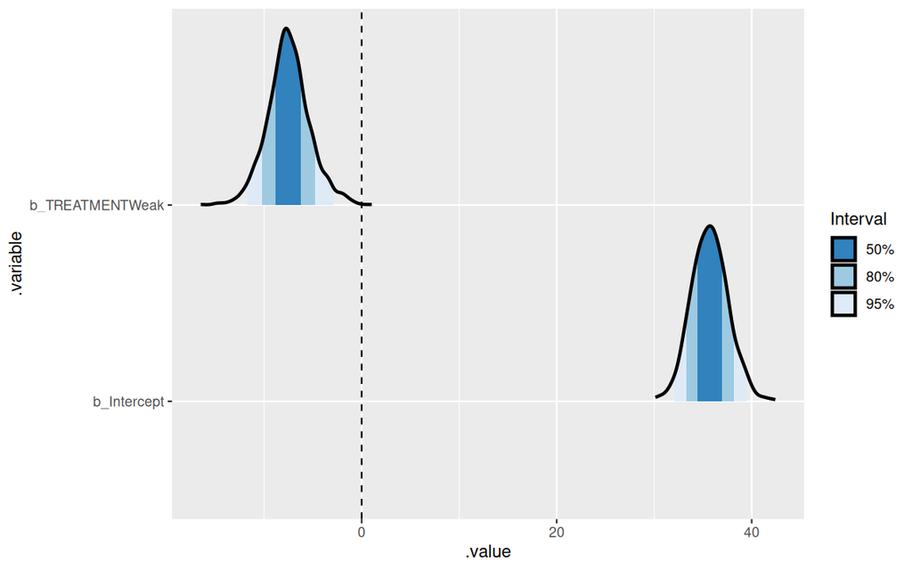

```r
tobacco_brm3 |>
    gather_draws(`b_Intercept.*|b_TREAT.*`, regex=TRUE) |>
    ggplot() +
    geom_vline(xintercept=0, linetype='dashed') +
    stat_slab(aes(x = .value, y = .variable,
                  fill = stat(ggdist::cut_cdf_qi(cdf,
                           .width = c(0.5, 0.8, 0.95),
                           labels = scales::percent_format())
                           )), color='black') +
    scale_fill_brewer('Interval', direction = -1, na.translate = FALSE)
```

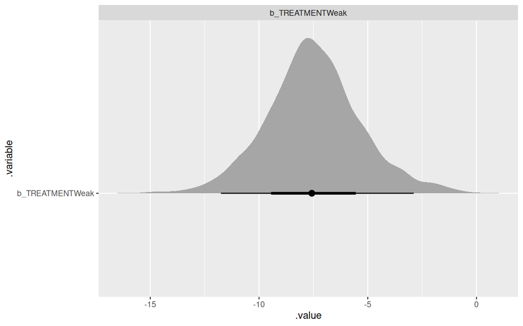

```r
tobacco_brm3 |>
  gather_draws(`.Intercept.*|.*TREAT.*`, regex=TRUE) |>
  ggplot() +
  stat_halfeye(aes(x=.value,  y=.variable)) +
  facet_wrap(~.variable, scales='free')
```

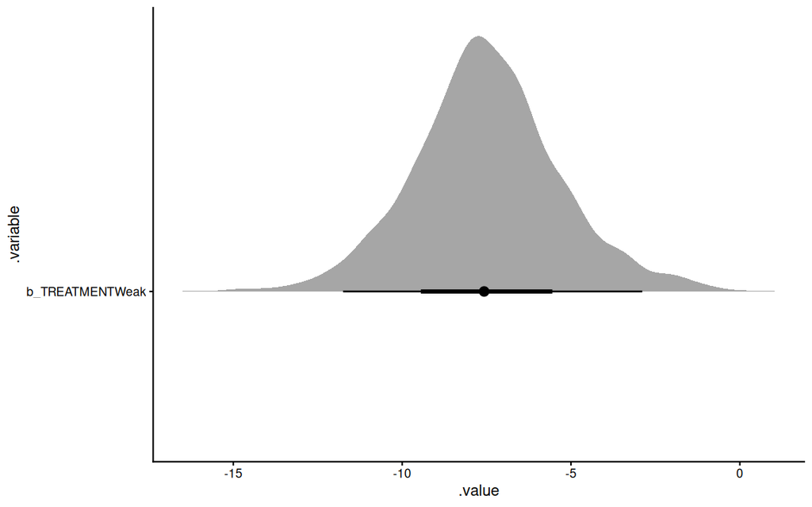

```r
tobacco_brm3 |>
  gather_draws(`.Intercept.*|.*TREAT.*`, regex=TRUE) |>
  ggplot() +
    stat_halfeye(aes(x=.value,  y=.variable)) +
    theme_classic()
```

**bayesplot**

```
'pars' not specified. Showing first 10 parameters by default.
```

```
ci_level: 0.8 (80% intervals)
```

```
outer_level: 0.95 (95% intervals)
```

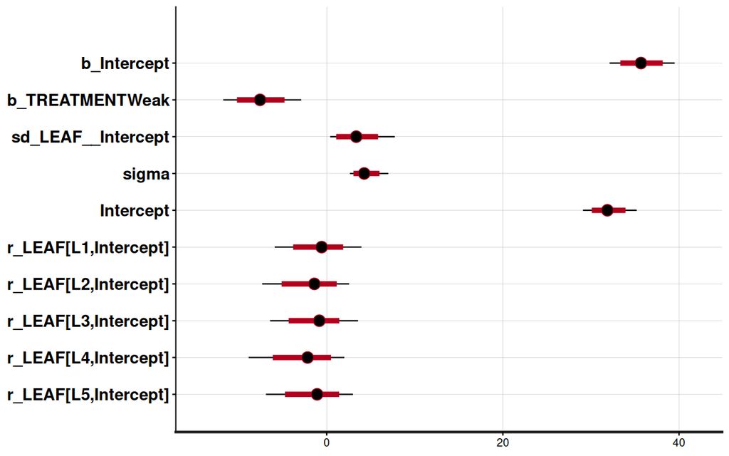

```r
tobacco_brm3$fit |> plot(type='intervals')
```

**half-eye (ggdist)**

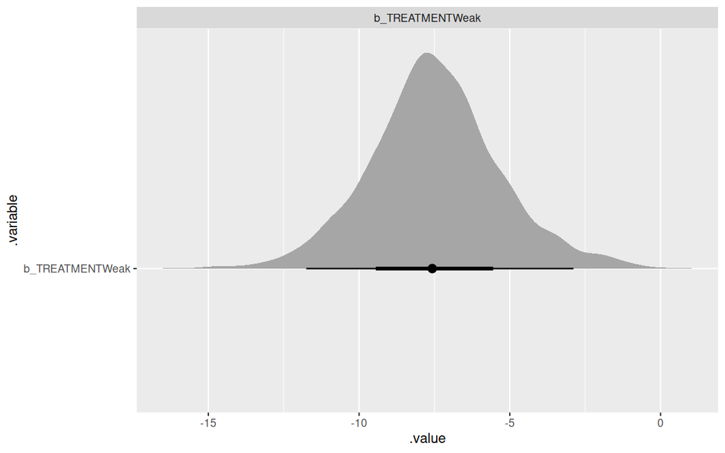

```r
tobacco_brm3 |>
    gather_draws(`^b_.*`, regex=TRUE) |>
    filter(.variable != 'b_Intercept') |>
    ggplot() +
    stat_halfeye(aes(x=.value,  y=.variable)) +
    facet_wrap(~.variable, scales='free')
```

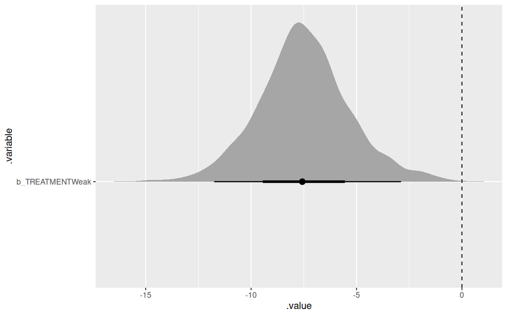

```r
tobacco_brm3 |>
    gather_draws(`^b_.*`, regex=TRUE) |>
    filter(.variable != 'b_Intercept') |>
    ggplot() +
    stat_halfeye(aes(x=.value,  y=.variable)) +
    geom_vline(xintercept = 0, linetype = 'dashed')
```

**density ridges (ggridges)**

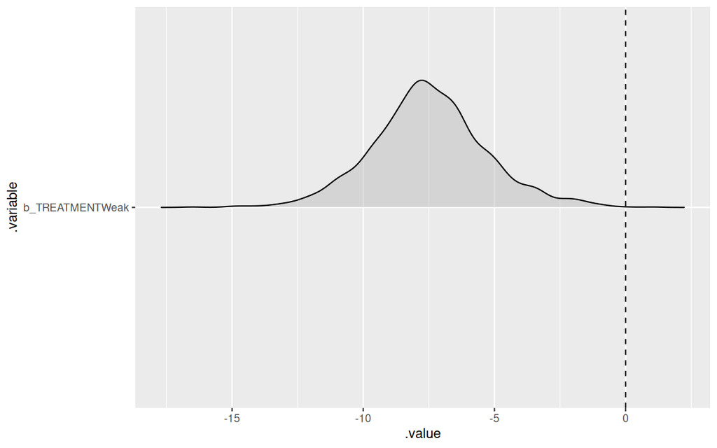

```r
tobacco_brm3 |>
    gather_draws(`^b_.*`, regex=TRUE) |>
    filter(.variable != 'b_Intercept') |>
    ggplot() +
    geom_density_ridges(aes(x=.value, y = .variable), alpha=0.4) +
    geom_vline(xintercept = 0, linetype = 'dashed')
```

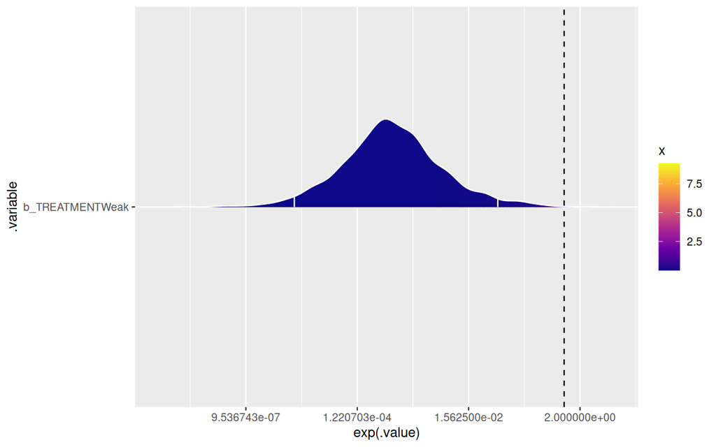

```r
##Or in colour
tobacco_brm3 |>
    gather_draws(`^b_.*`, regex=TRUE) |>
    filter(.variable != 'b_Intercept') |>
    ggplot() +
    geom_density_ridges_gradient(aes(x=exp(.value),
                                     y = .variable,
                                     fill = stat(x)),
                                 alpha=0.4, colour = 'white',
                                 quantile_lines = TRUE,
                                 quantiles = c(0.025, 0.975)) +
    geom_vline(xintercept = 1, linetype = 'dashed') +
    scale_x_continuous(trans = scales::log2_trans()) +
    scale_fill_viridis_c(option = "C")
```

**tidy_draws**

```r
tobacco_brm3 |> tidy_draws()
```

```
# A tibble: 1,500 × 28
   .chain .iteration .draw b_Intercept b_TREATMENTWeak sd_LEAF__Intercept sigma
    <int>      <int> <int>       <dbl>           <dbl>              <dbl> <dbl>
 1      1          1     1        34.9           -7.69               3.70  5.18
 2      1          2     2        36.1           -5.11               1.12  5.96
 3      1          3     3        36.0           -7.67               5.15  5.29
 4      1          4     4        37.7           -7.93               4.91  5.06
 5      1          5     5        39.5          -10.1                4.26  3.27
 6      1          6     6        30.1           -6.91               5.10  3.28
 7      1          7     7        33.8           -9.17               8.40  4.70
 8      1          8     8        39.0           -9.23               3.99  2.70
 9      1          9     9        36.5           -8.66               3.92  2.62
10      1         10    10        39.8          -10.4                4.14  5.18
# ℹ 1,490 more rows
# ℹ 21 more variables: Intercept <dbl>, `r_LEAF[L1,Intercept]` <dbl>,
#   `r_LEAF[L2,Intercept]` <dbl>, `r_LEAF[L3,Intercept]` <dbl>,
#   `r_LEAF[L4,Intercept]` <dbl>, `r_LEAF[L5,Intercept]` <dbl>,
#   `r_LEAF[L6,Intercept]` <dbl>, `r_LEAF[L7,Intercept]` <dbl>,
#   `r_LEAF[L8,Intercept]` <dbl>, prior_Intercept <dbl>, prior_b <dbl>,
#   prior_sigma <dbl>, prior_sd_LEAF <dbl>, lprior <dbl>, lp__ <dbl>, …
```

**spread_draws**

```r
tobacco_brm3 |> spread_draws(`.*Intercept.*|.*TREAT.*`,  regex=TRUE)
```

```
# A tibble: 1,500 × 16
   .chain .iteration .draw b_Intercept b_TREATMENTWeak sd_LEAF__Intercept
    <int>      <int> <int>       <dbl>           <dbl>              <dbl>
 1      1          1     1        34.9           -7.69               3.70
 2      1          2     2        36.1           -5.11               1.12
 3      1          3     3        36.0           -7.67               5.15
 4      1          4     4        37.7           -7.93               4.91
 5      1          5     5        39.5          -10.1                4.26
 6      1          6     6        30.1           -6.91               5.10
 7      1          7     7        33.8           -9.17               8.40
 8      1          8     8        39.0           -9.23               3.99
 9      1          9     9        36.5           -8.66               3.92
10      1         10    10        39.8          -10.4                4.14
# ℹ 1,490 more rows
# ℹ 10 more variables: Intercept <dbl>, `r_LEAF[L1,Intercept]` <dbl>,
#   `r_LEAF[L2,Intercept]` <dbl>, `r_LEAF[L3,Intercept]` <dbl>,
#   `r_LEAF[L4,Intercept]` <dbl>, `r_LEAF[L5,Intercept]` <dbl>,
#   `r_LEAF[L6,Intercept]` <dbl>, `r_LEAF[L7,Intercept]` <dbl>,
#   `r_LEAF[L8,Intercept]` <dbl>, prior_Intercept <dbl>
```

**posterior_samples**

```r
tobacco_brm3 |> posterior_samples() |> as_tibble()
```

```
# A tibble: 1,500 × 19
   b_Intercept b_TREATMENTWeak sd_LEAF__Intercept sigma Intercept
         <dbl>           <dbl>              <dbl> <dbl>     <dbl>
 1        34.9           -7.69               3.70  5.18      31.0
 2        36.1           -5.11               1.12  5.96      33.6
 3        36.0           -7.67               5.15  5.29      32.2
 4        37.7           -7.93               4.91  5.06      33.7
 5        39.5          -10.1                4.26  3.27      34.4
 6        30.1           -6.91               5.10  3.28      26.7
 7        33.8           -9.17               8.40  4.70      29.2
 8        39.0           -9.23               3.99  2.70      34.4
 9        36.5           -8.66               3.92  2.62      32.1
10        39.8          -10.4                4.14  5.18      34.6
# ℹ 1,490 more rows
# ℹ 14 more variables: `r_LEAF[L1,Intercept]` <dbl>,
#   `r_LEAF[L2,Intercept]` <dbl>, `r_LEAF[L3,Intercept]` <dbl>,
#   `r_LEAF[L4,Intercept]` <dbl>, `r_LEAF[L5,Intercept]` <dbl>,
#   `r_LEAF[L6,Intercept]` <dbl>, `r_LEAF[L7,Intercept]` <dbl>,
#   `r_LEAF[L8,Intercept]` <dbl>, prior_Intercept <dbl>, prior_b <dbl>,
#   prior_sigma <dbl>, prior_sd_LEAF <dbl>, lprior <dbl>, lp__ <dbl>
```

**\(R^2\)**

```r
tobacco_brm3 |>
    bayes_R2(re.form = NA, summary=FALSE) |>
    median_hdci()
```

```
          y       ymin      ymax .width .point .interval
1 0.3681348 0.08037349 0.5560543   0.95 median      hdci
```

```r
tobacco_brm3 |>
    bayes_R2(re.form = ~(1|LEAF), summary=FALSE) |>
    median_hdci()
```

```
          y      ymin      ymax .width .point .interval
1 0.6169173 0.2089457 0.8279478   0.95 median      hdci
```

```r
tobacco_brm3 |>
     bayes_R2(re.form = ~(TREATMENT|LEAF), summary=FALSE) |>
     median_hdci()
```

```
          y       ymin      ymax .width .point .interval
1 0.3681348 0.08037349 0.5560543   0.95 median      hdci
```

**ROPE**

Region of Practical Equivalence

```r
0.1 * sd(tobacco$NUMBER)
```

```
[1] 0.6540458
```

```r
tobacco_brm3 |> rope(range = c(-0.65, 0.65))
```

```
# Proportion of samples inside the ROPE [-0.65, 0.65]:

Parameter     | Inside ROPE
---------------------------
Intercept     |      0.00 %
TREATMENTWeak |      0.00 %
```

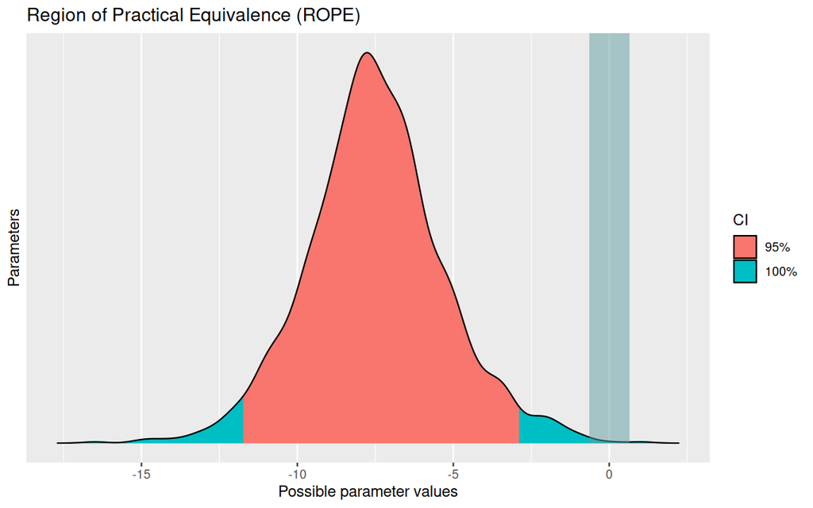

```r
rope(tobacco_brm3, range = c(-0.65, 0.65)) |> plot()
```

```r
## Or based on fractional scale
tobacco_brm3 |> emmeans(~TREATMENT) |>
    gather_emmeans_draws() |>
    group_by(.draw) |>
    arrange(desc(TREATMENT)) |>
    summarise(Diff = 100*(exp(diff(log(.value))) -1)) |>
    rope(range = c(-10,10))
```

[output not shown]

**Modelsummary**

```r
tobacco_brm3 |> modelsummary(
  statistic = c("conf.low", "conf.high"),
  shape = term ~ statistic,
  exponentiate = TRUE
)
```

[output not shown]

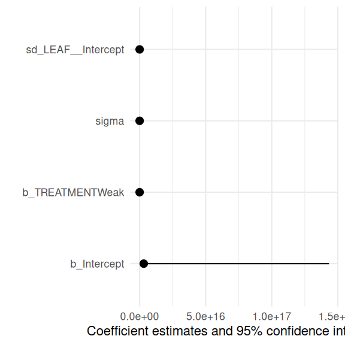

```r
tobacco_brm3 |> modelplot(exponentiate = TRUE)
```

# 9 Further investigations

**brms**

**Via emmeans**

```r
tobacco_brm3 |> emmeans(~TREATMENT) |>
    gather_emmeans_draws() |>
    group_by(.draw) |>
    arrange(desc(TREATMENT)) |>
    summarise(Diff = 100*(exp(diff(log(.value))) -1)) |>
    summarise_draws(
        median,
        ~ HDInterval::hdi(.x),
        rhat,
        ess_bulk,
        ess_tail
        )
```

```
# A tibble: 1 × 7
  variable median lower upper  rhat ess_bulk ess_tail
  <chr>     <dbl> <dbl> <dbl> <dbl>    <dbl>    <dbl>
1 Diff       27.0  9.66  45.8  1.00    1615.    1513.
```

```r
## Or via gather and pivot
newdata <- tobacco_brm3 |>
    emmeans(~TREATMENT) |>
    gather_emmeans_draws() |>
    pivot_wider(names_from=TREATMENT,values_from=.value) |>
    mutate(Eff = Strong - Weak,
           PEff = 100*Eff/Weak)
newdata |> median_hdci(PEff)
```

```
# A tibble: 1 × 6
   PEff .lower .upper .width .point .interval
  <dbl>  <dbl>  <dbl>  <dbl> <chr>  <chr>
1  27.0   9.66   45.8   0.95 median hdci
```

```r
newdata |> summarise(P = mean(PEff>0))
```

```
# A tibble: 1 × 1
      P
  <dbl>
1 0.999
```

```r
newdata |> summarise(P = mean(PEff>20))
```

```
# A tibble: 1 × 1
      P
  <dbl>
1 0.803
```

```r
newdata |>
    dplyr::select(-.chain, -.iteration) |>
    hypothesis('PEff>20')
```

```
Hypothesis Tests for class :
       Hypothesis Estimate Est.Error CI.Lower CI.Upper Evid.Ratio Post.Prob
1 (PEff)-(20) > 0     6.97      8.98    -7.74    22.47       4.08       0.8
  Star
1
---
'CI': 90%-CI for one-sided and 95%-CI for two-sided hypotheses.
'*': For one-sided hypotheses, the posterior probability exceeds 95%;
for two-sided hypotheses, the value tested against lies outside the 95%-CI.
Posterior probabilities of point hypotheses assume equal prior probabilities.
```

```r
newdata <- tobacco_brm3 |> emmeans(~TREATMENT) |> as.data.frame()
head(newdata)
```

```
 TREATMENT   emmean lower.HPD upper.HPD
 Strong    35.67776  31.97558  39.39172
 Weak      28.15988  24.65481  32.11096

Point estimate displayed: median
HPD interval probability: 0.95
```

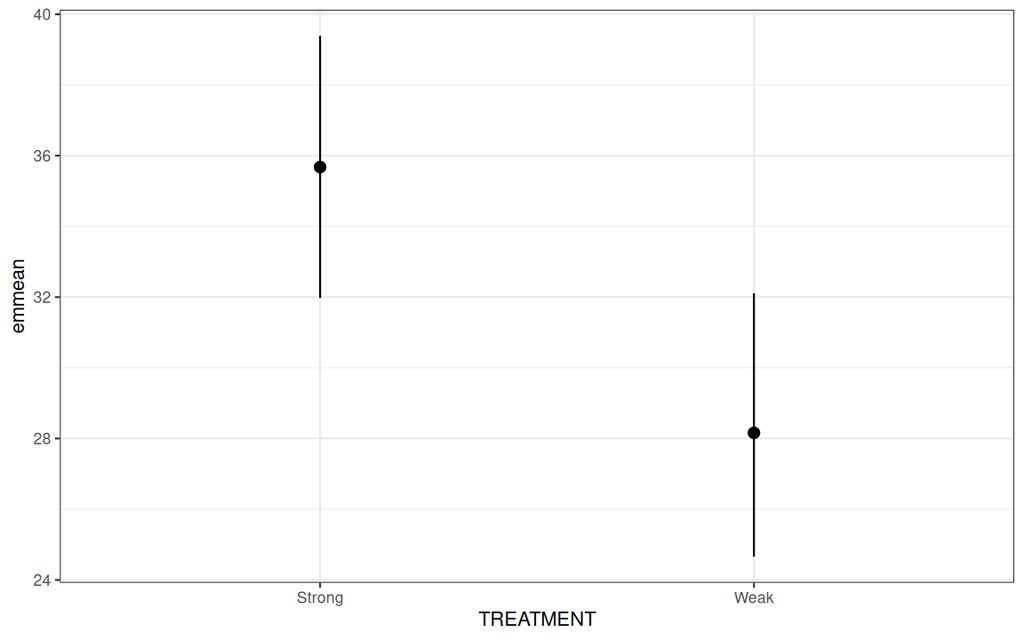

```r
ggplot(newdata, aes(y=emmean, x=TREATMENT)) +
    geom_pointrange(aes(ymin=lower.HPD, ymax=upper.HPD)) +
    theme_bw()
```

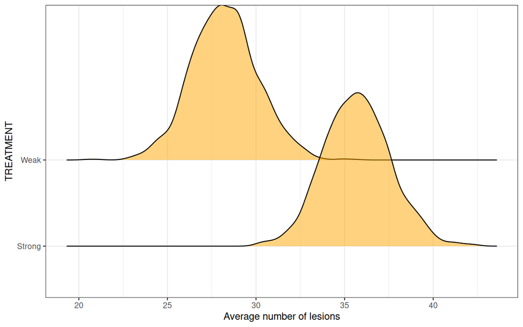

```r
tobacco_brm3 |>
    emmeans(~TREATMENT) |>
    gather_emmeans_draws() |>
    ggplot() +
    geom_density_ridges(aes(x = .value, y = TREATMENT), alpha = 0.5, fill = 'orange') +
    scale_x_continuous("Average number of lesions") +
    theme_bw()
```

**Via posterior_epred**

```r
newdat <- tobacco |> tidyr::expand(TREATMENT)
newdata <- tobacco_brm3 |>
    brms::posterior_epred(newdat, re_formula = NA) |>
    as.data.frame() |>
    rename_with(~as.character(newdat$TREATMENT)) |>
    mutate(Eff = Strong - Weak,
           PEff = 100*Eff/Weak)
head(newdata)
```

```
    Strong     Weak       Eff     PEff
1 34.88886 27.20242  7.686442 28.25646
2 36.13339 31.02746  5.105929 16.45616
3 35.99507 28.32387  7.671205 27.08389
4 37.66234 29.73113  7.931213 26.67647
5 39.48927 29.35940 10.129868 34.50298
6 30.12279 23.21473  6.908059 29.75723
```

```r
newdata |> median_hdci(PEff)
```

```
# A tibble: 1 × 6
   PEff .lower .upper .width .point .interval
  <dbl>  <dbl>  <dbl>  <dbl> <chr>  <chr>
1  27.0   9.66   45.8   0.95 median hdci
```

```r
newdata |> summarise(P = mean(PEff>0))
```

```
          P
1 0.9986667
```

```r
newdata |> summarise(P = mean(PEff>20))
```

```
          P
1 0.8033333
```

**Via emmeans and pairs**

```r
newdata <- tobacco_brm3 |>
    emmeans(~TREATMENT) |>
    pairs() |>
    gather_emmeans_draws()
newdata |> median_hdci()
```

```
# A tibble: 1 × 7
  contrast      .value .lower .upper .width .point .interval
  <chr>          <dbl>  <dbl>  <dbl>  <dbl> <chr>  <chr>
1 Strong - Weak   7.57   3.18   12.0   0.95 median hdci
```

```r
## OR on percentage scale
newdata <- tobacco_brm3 |>
    emmeans(~TREATMENT) |>
    regrid(trans = 'log') |>
    pairs() |>
    regrid() |>
    gather_emmeans_draws() |>
    mutate(.value = (.value - 1) * 100)
newdata |> median_hdci()
```

```
# A tibble: 1 × 7
  contrast    .value .lower .upper .width .point .interval
  <chr>        <dbl>  <dbl>  <dbl>  <dbl> <chr>  <chr>
1 Strong/Weak   27.0   9.66   45.8   0.95 median hdci
```

```r
newdata |> summarise(P = mean(.value>0))
```

```
# A tibble: 1 × 2
  contrast        P
  <chr>       <dbl>
1 Strong/Weak 0.999
```

```r
newdata |> summarise(P = mean(.value>20))
```

```
# A tibble: 1 × 2
  contrast        P
  <chr>       <dbl>
1 Strong/Weak 0.803
```

# 10 References